# Lab 1 - Intro to R and RStudio - KEY

Total: 90 pts

## Lab report

**Load Arbuthnot data**

```r
load(url("https://stat.duke.edu/~mc301/data/arbuthnot.RData"))
```

#### Exercise 1:

```
5 pts - no narrative needed
```

Either of the following is considered correct:

```r
arbuthnot$girls
```

```
##  [1] 4683 4457 4102 4590 4839 4820 4928 4605 4457 4952 4784 5332 5200 4910
## [15] 4617 3997 3919 3395 3536 3181 2746 2722 2840 2908 2959 3179 3349 3382
## [29] 3289 3013 2781 3247 4107 4803 4881 5681 4858 4319 5322 5560 5829 5719
## [43] 6061 6120 5822 5738 5717 5847 6203 6033 6041 6299 6533 6744 7158 7127
## [57] 7246 7119 7214 7101 7167 7302 7392 7316 7483 6647 6713 7229 7767 7626
## [71] 7452 7061 7514 7656 7683 5738 7779 7417 7687 7623 7380 7288
```

```r
arbuthnot %>%
  select(girls)
```

```
## # A tibble: 82 x 1
##    girls
##    <int>
##  1  4683
##  2  4457
##  3  4102
##  4  4590
##  5  4839
##  6  4820
##  7  4928
##  8  4605
##  9  4457
## 10  4952
## # … with 72 more rows
```

#### Exercise 2:

```
15 pts:
* 7 pts for plot
* 8 pts for interpretation
```

- The overall trend of number of girls baptized over years is upwards. (2 pts)
- However there is a sharp dip between 1640 - 1650. Baptisms of girls pick up again in 1660. (4 pts)
- The rate of increase slows down around 1690. (2 pts)

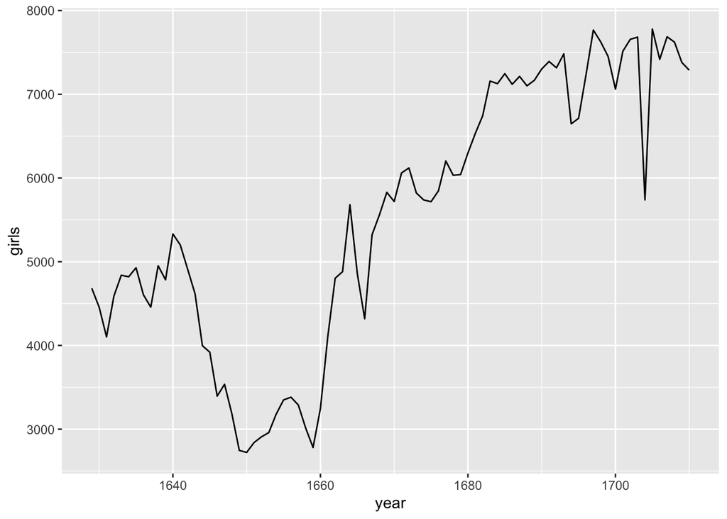

```r
qplot(x = year, y = girls, data = arbuthnot, geom = "line")
```

#### Exercise 3:

```
20 pts:
* 6 pts for creating the new variables
* 6 pts for plot
* 8 pts for interpretation
```

- The proportions of boys baptized each year are slightly over 50%. (4 pts)
- There are cyclical patterns but overall there seems to be a slight decrease in the proportions over time. (4 pts)

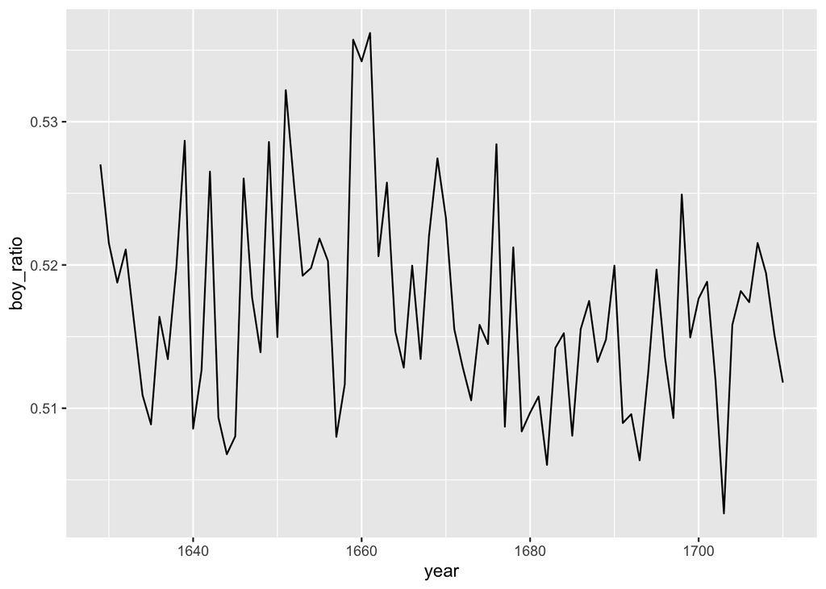

```r
arbuthnot <- arbuthnot %>%
  mutate(total = boys + girls) %>%
  mutate(boy_ratio = boys / total)

qplot(x = year, y = boy_ratio, data = arbuthnot, geom = "line")
```

### More practice

**Load present day data**

```r
load(url("https://stat.duke.edu/~mc301/data/present.RData"))
```

#### 4:

```
15 pts
```

- The years included in the dataset are 1940 - 2013. (5 pts)
- The dataframe has 74 observations and 3 variables. (5 pts)
- The variables are `year`, `boys` (number of boys born), and `girls` (number of girls born). (5 pts)

#### 5:

```
5 pts
```

The counts are much higher than in the Arbuthnot data set, they are not on the same scale.

#### 6:

```
20 pts:
* 5 pts for creating the new variables
* 5 pts for plot
* 10 pts for interpretation
```

- Arbuthnot’s observation about boys being born in greater proportion than girls holds up in the U.S. as well. (5 pts)
- However while the ratio of boys is much higher than girls in the 1940s, the ratio decreases and approaches 50% throughout time. (5 pts)

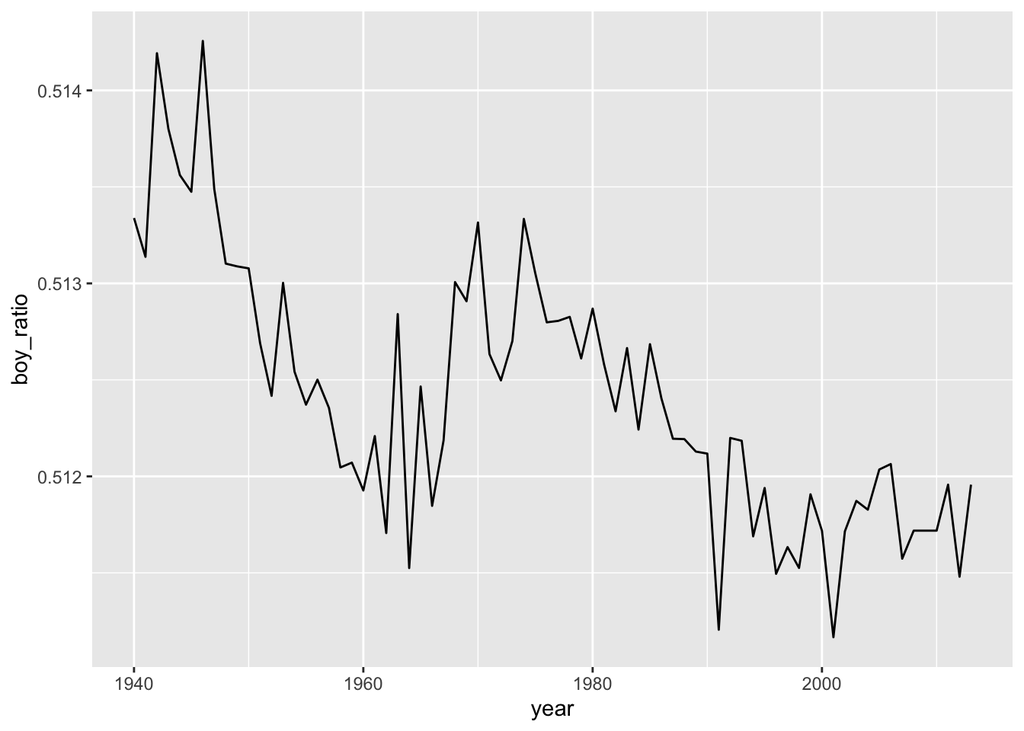

```r
present <- present %>%
  mutate(total = boys + girls) %>%
  mutate(boy_ratio = boys / total)

qplot(x = year, y = boy_ratio, data = present, geom = "line")
```

#### 7:

```
10 pts:
* 8 pts for code
* 2 pts for answer in text
```

We saw the most number of births in 2007.

```r
present %>%
  arrange(desc(total))
```

```
## # A tibble: 74 x 5
##     year    boys   girls   total boy_ratio
##    <dbl>   <dbl>   <dbl>   <dbl>     <dbl>
##  1  2007 2208071 2108162 4316233     0.512
##  2  1961 2186274 2082052 4268326     0.512
##  3  2006 2184237 2081318 4265555     0.512
##  4  1960 2179708 2078142 4257850     0.512
##  5  1957 2179960 2074824 4254784     0.512
##  6  2008 2173625 2074069 4247694     0.512
##  7  1959 2173638 2071158 4244796     0.512
##  8  1958 2152546 2051266 4203812     0.512
##  9  1962 2132466 2034896 4167362     0.512
## 10  1956 2133588 2029502 4163090     0.513
## # … with 64 more rows
```